# Untitled

Introduction:

Urban Ministries is a non-profit organization that seeks to provide food, job opportunities, and other services to the homeless community of Durham and the surrounding area. Using the data provided by UM, I hope to provide meaningful insight into how the services they provide have changed over time, particularly with respect to the amount of food and school supplies the organization has provided to their clientele.

First, I decided to see if the amount of food and school supplies provided by the charity using two separate linear models. In both cases, I only used data starting from 1990, as this was the point when data started to be collected on a continuous basis. Additionally, I chose to run two separate models as the amount of times food was provided far exceeded the amount of times school supplies were provided, and to include them both in a single model would lead to the majority of food observations being dropped from the analysis, due to missing values for school supplies provided.

```r
UMD.data=fread(file="C:/Users/alex/Documents/GitHub/bios611-projects-fall-2019-arquinter/project_1/data/UMD_Services_Provided_20190719.tsv")
UMD.derived = UMD.data %>% mutate(ndate=as.Date(Date, "%m/%d/%Y")) %>% mutate(year=as.factor(format(as.Date(Date, "%m/%d/%Y"), "%Y")))
food.reg.df = na.omit(select(UMD.derived, ndate, year, `Food Pounds`)) %>%
  filter(!year %in% c("1931", "1941", "1951", "1961", "1971", "1981"), `Food Pounds` < 1000) %>% droplevels()
school.reg.df = na.omit(select(UMD.derived, ndate, year, `School Kits`)) %>%
  filter(!year %in% c("1931", "1941", "1951", "1961", "1971", "1981")) %>% droplevels()
summary(lm(`Food Pounds`~ndate, data = food.reg.df))
```

```
##
## Call:
## lm(formula = `Food Pounds` ~ ndate, data = food.reg.df)
##
## Residuals:
##    Min     1Q Median     3Q    Max
## -29.60 -10.19  -2.50   8.22 481.58
##
## Coefficients:
##               Estimate Std. Error t value Pr(>|t|)
## (Intercept) -3.469e+01  7.032e-01  -49.34   <2e-16 ***
## ndate        3.345e-03  4.418e-05   75.71   <2e-16 ***
## ---
## Signif. codes:  0 '***' 0.001 '**' 0.01 '*' 0.05 '.' 0.1 ' ' 1
##
## Residual standard error: 15.8 on 67259 degrees of freedom
## Multiple R-squared:  0.07852,    Adjusted R-squared:  0.07851
## F-statistic:  5731 on 1 and 67259 DF,  p-value: < 2.2e-16
```

```r
summary(aov(`Food Pounds`~year, data = food.reg.df))
```

```
##                Df   Sum Sq Mean Sq F value Pr(>F)
## year           24  1580608   65859   266.3 <2e-16 ***
## Residuals   67236 16631182     247
## ---
## Signif. codes:  0 '***' 0.001 '**' 0.01 '*' 0.05 '.' 0.1 ' ' 1
```

```r
summary(lm(`School Kits`~ndate, data = school.reg.df))
```

```
##
## Call:
## lm(formula = `School Kits` ~ ndate, data = school.reg.df)
##
## Residuals:
##      Min       1Q   Median       3Q      Max
## -11.2251  -0.1390  -0.1268  -0.1045  16.4076
##
## Coefficients:
##               Estimate Std. Error t value Pr(>|t|)
## (Intercept) -2.402e+01  1.987e+00  -12.09   <2e-16 ***
## ndate        2.033e-03  1.574e-04   12.91   <2e-16 ***
## ---
## Signif. codes:  0 '***' 0.001 '**' 0.01 '*' 0.05 '.' 0.1 ' ' 1
##
## Residual standard error: 3.282 on 180 degrees of freedom
## Multiple R-squared:  0.4809, Adjusted R-squared:  0.478
## F-statistic: 166.8 on 1 and 180 DF,  p-value: < 2.2e-16
```

```r
summary(aov(`School Kits`~year, data = school.reg.df))
```

```
##              Df Sum Sq Mean Sq F value Pr(>F)
## year         14   2605  186.08    27.5 <2e-16 ***
## Residuals   167   1130    6.77
## ---
## Signif. codes:  0 '***' 0.001 '**' 0.01 '*' 0.05 '.' 0.1 ' ' 1
```

From the constructed ANOVA models, it was clear that the average amount of food and school supplies provided were not constant over time, the significant value of the slope of the regression line pointed to a possible linear trend.

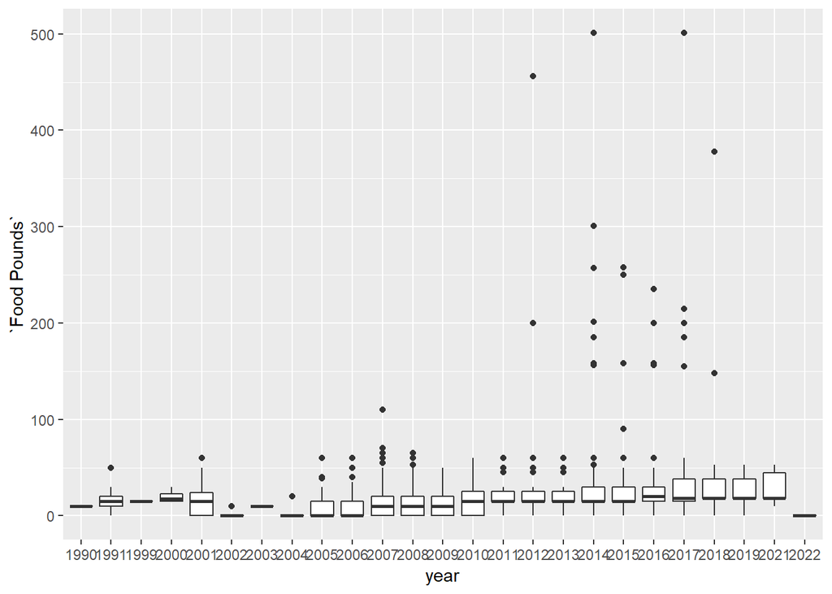

```r
ggplot(food.reg.df, aes(x=year, y=`Food Pounds`)) + geom_boxplot()
```

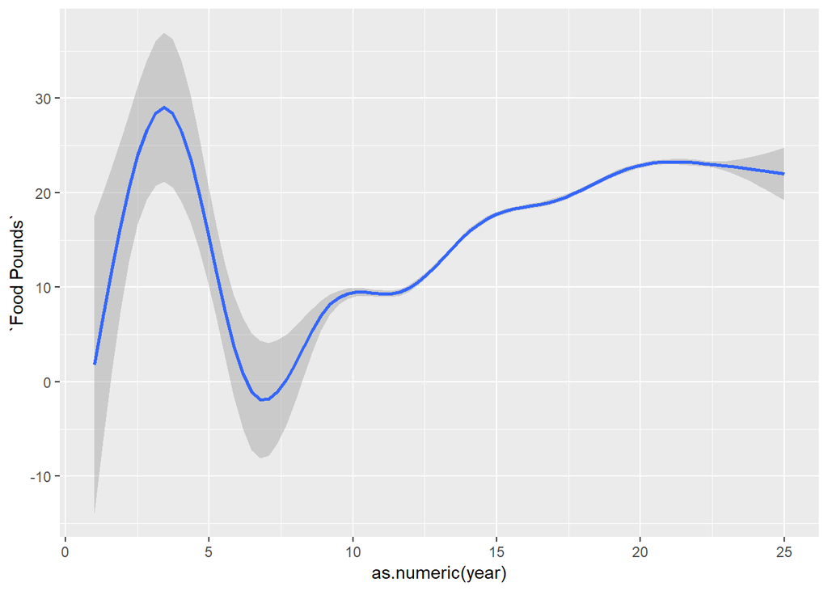

```r
ggplot(food.reg.df, aes(x=as.numeric(year), y=`Food Pounds`)) + geom_smooth()
```

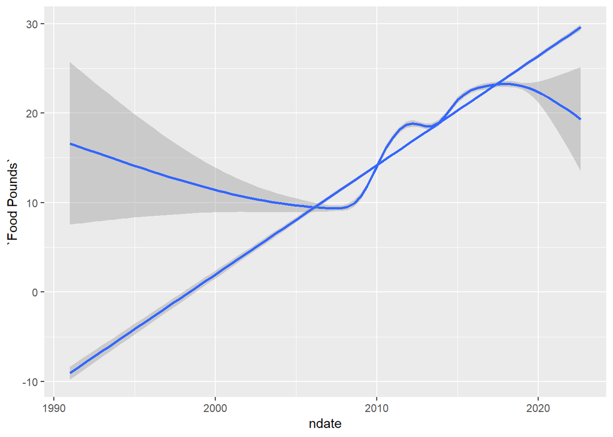

```r
ggplot(food.reg.df, aes(x=ndate, y=`Food Pounds`)) + geom_smooth() + geom_smooth(method = "lm")
```

However, plotting a generalized additive model (GAM) to the food data indicated that the amount of food provided did not change constantly over time, but rather varied greatly. However, it did seem to be the case that the amount of food provided did indeed increase over time, though not at a constant rate.

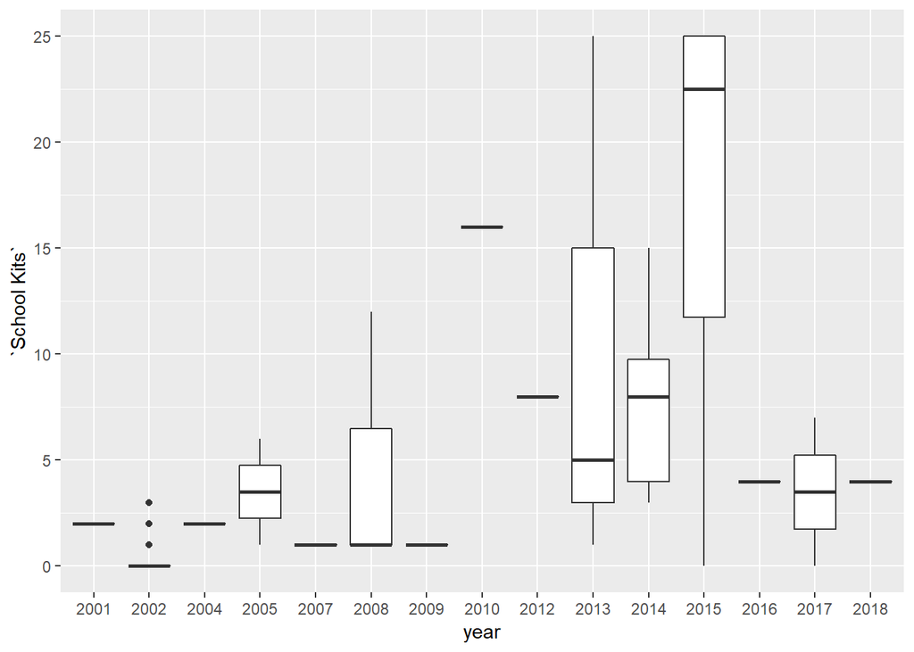

```r
ggplot(school.reg.df, aes(x=year, y=`School Kits`)) + geom_boxplot()
```

[figure not shown]

```r
ggplot(school.reg.df, aes(x=as.numeric(year), y=`School Kits`)) + geom_smooth()
```

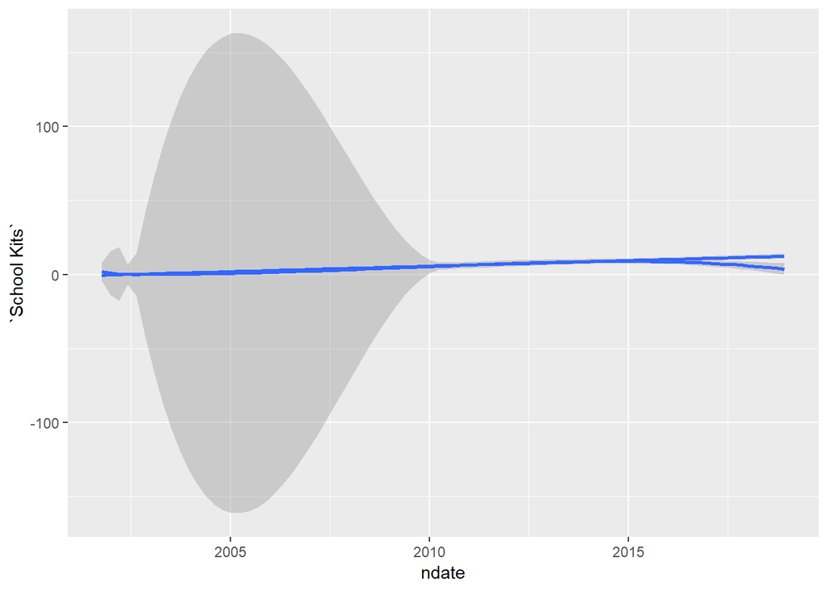

```r
ggplot(school.reg.df, aes(x=ndate, y=`School Kits`)) + geom_smooth() + geom_smooth(method = "lm")
```

When plotting the GAM and linear model to the school kits data, I found that the amount of school kits provided did seem to increase at a constant rate over time. The GAM however seems to indicate that the amount of school kits provided has dropped slightly in the last couple years.